# Olympiades project

#### Compare Age

```r
wilcox.test(Winter$Age[Winter$Sex == "M"],
            Winter$Age[Winter$Sex == "F"])
```

```
##
##  Wilcoxon rank sum test with continuity correction
##
## data:  Winter$Age[Winter$Sex == "M"] and Winter$Age[Winter$Sex == "F"]
## W = 294473922, p-value < 2.2e-16
## alternative hypothesis: true location shift is not equal to 0
```

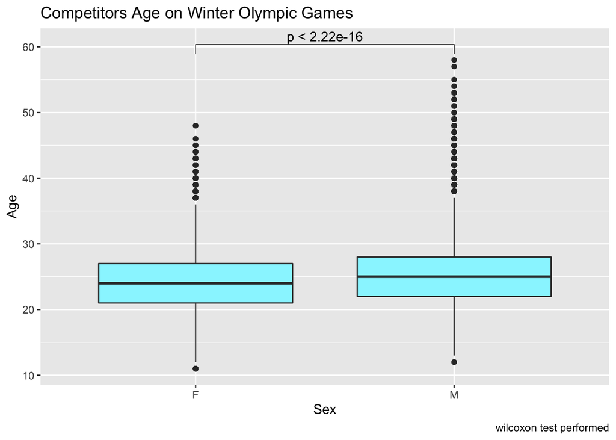

```r
ggplot(Winter, aes(x = Sex, y = Age))+
  geom_boxplot(fill = "cadetblue1")+
  stat_compare_means(method = "wilcox.test", comparisons = list(c("F", "M")))+
  labs(title = "Competitors Age on Winter Olympic Games",
       caption = "wilcoxon test performed" )
```

### Inspect the connection between Team and medal

```r
Medals <- filter(filt_frame, Medal != "participant")
Medals$Medal <- 1
Tab_Medals <- table(Medals$Team, Medals$Medal)
chisq.test(Tab_Medals)
```

```
##
##  Chi-squared test for given probabilities
##
## data:  Tab_Medals
## X-squared = 715762, df = 482, p-value < 2.2e-16
```

### Explore the most “Young” and the most “Elder” sport

We firstly search for the sports with minimum and maximum mean age

```r
sport_with_min_max_mean_age <- group_by(filt_frame, Sport) %>%
  summarise(mean_Age = round(mean(Age), digits = 3)) %>%
  filter(mean_Age %in% c(max(mean_Age), min(mean_Age)))
tableHTML(sport_with_min_max_mean_age)
```

|  | Sport | mean_Age |
| --- | --- | --- |
| 1 | Rhythmic Gymnastics | 18.737 |
| 2 | Roque | 53.333 |

Then we calculated the number of observations connected with these sports

```r
Rhythmic_Gymnastics <- filter(filt_frame, Sport == "Rhythmic Gymnastics")
nrow(Rhythmic_Gymnastics)
```

```
## [1] 658
```

```r
Roque <- filter(filt_frame, Sport == "Roque")
nrow(Roque)
```

```
## [1] 3
```

It turned out that there are to little observations in sport Roque. But it is still worthly to work with Rhythmic Gymnastics. We calculated mean age throughout the dataframe to compare it with mean age of Rhythmic Gymnastics

```r
global_mean_age <- mean(filt_frame$Age)
global_mean_age
```

```
## [1] 25.55768
```

Since the number of observations in Rhythmic Gymnastics seem to allow us to use t-test we dropped duplicated names so there is no more dependent observations. Then calculated the number of observations again

```r
Rhythmic_Gymnastics_unique <- distinct(Rhythmic_Gymnastics, Name, .keep_all = T)
nrow(Rhythmic_Gymnastics_unique)
```

```
## [1] 567
```

Performed t-test showed that competitors in Rhythmic Gymnastics have significantly different average age in comparison to average age of overall competitors

```r
t.test(Rhythmic_Gymnastics_unique$Age, mu = global_mean_age,
       alternative = "two.sided")
```

```
##
##  One Sample t-test
##
## data:  Rhythmic_Gymnastics_unique$Age
## t = -82.488, df = 566, p-value < 2.2e-16
## alternative hypothesis: true mean is not equal to 25.55768
## 95 percent confidence interval:
##  18.03130 18.38139
## sample estimates:
## mean of x
##  18.20635
```